# ACA3: School Clustering

### Application of the KMeans and Principal Component Analysis

**Task**  
Analyze the data of `CollegeScorecard.csv` to identify clusters of similar colleges and universities.

**Premise**

1. We want to support incoming families/students distinguish affordable and high-quality schools in safe neighborhoods that have access to transit and employment.
2. We want to provide decision-makers and parents distinguish the disparities of outcomes among different student groups.

**Topics of Interest**  
-School quality (retention rates, diversity, graduation rates, etc)  
-Safety (we will define safety as the number of violent crimes in the city that the school is located in)  
-Transit (we will analyze transit based on the population of the city that the school is located in- we assume that bigger cities are likely to have better transporation infrastructures)  
-Employment

**Strategy**  
We will manually select a subset of columns that can be considered to be reasonably related to the above topics of interest. By conducting PCA on the selected variables, we will determine which of the selected variables are particularly relevant.  
Finally, upon fitting the original data onto the found eigenvectors, we will determine the number of clusters that the schools ought to be divided into, and visualize the clusters on a two-dimensional scatterplot.  
We will conduct the analysis on two types of data: the first containing data from the original `CollegeScorecard.csv`, and the second containing additional data merged from `Crime_New.csv`.

**Reference; Crime_New.csv**  
Source: https://ucr.fbi.gov/crime-in-the-u.s/2019/crime-in-the-u.s.-2019/tables/table-8/table-8.xls/view  
Titles and comments were removed from the original csv data; column name "Violentn\crime" was changed to "Violent crime"; the merged cells in column A containing the state names were unmerged and refilled.

```python
# Import matplotlob, numpy, and pandas
# Import dataset
import matplotlib.pyplot as plt
import numpy as np
import pandas as pd
from sklearn.decomposition import PCA
from sklearn.cluster import KMeans
from sklearn.metrics import silhouette_score
from sklearn import preprocessing
from yellowbrick.cluster import SilhouetteVisualizer

scorecard = pd.read_csv("Downloads/CollegeScorecard.csv")
crimes = pd.read_csv("Downloads/Crime_New.csv")
```

### Merging & Cleaning the Data

```python
# Select relevant columns from the scorecard data
sel_columns = ['INSTNM',
               'CITY',
               'STABBR',
               'UGDS',
               'HBCU',
               'PBI',
               'ANNHI',
               'TRIBAL',
               'AANAPII',
               'HSI',
               'NANTI',
               'MENONLY',
               'WOMENONLY',
               'UGDS_WHITE',
               'UGDS_BLACK',
               'UGDS_HISP',
               'UGDS_ASIAN',
               'UGDS_AIAN',
               'UGDS_NHPI',
               'UGDS_2MOR',
               'UGDS_NRA',
               'UGDS_UNKN',
               'UG25abv',
               'PAR_ED_PCT_1STGEN',
               'LOCALE',
               'RET_FT4',
               'RET_FTL4',
               'RPY_3YR_RT',
               'NPT4_PUB',
               'NPT4_PRIV',
               'C150_4',
               'C150_L4',
               'PCTFLOAN']
scorecard_sel = scorecard[sel_columns]
```

```python
# Merge crime data set

## From the crime data, select the state name,city name, population, and violent crime rates
crimes_sel = crimes[['State',
                     'Population',
                     'City',
                     'Violent crime']]

## Change state names to state abbreviations for merging purposes
us_state_to_abbrev = {
    "ALABAMA": "AL",
    "ALASKA": "AK",
    "ARIZONA": "AZ",
    "ARKANSAS": "AR",
    "CALIFORNIA": "CA",
    "COLORADO": "CO",
    "CONNECTICUT": "CT",
    "DELAWARE": "DE",
    "FLORIDA": "FL",
    "GEORGIA": "GA",
    "HAWAII": "HI",
    "IDAHO": "ID",
    "ILLINOIS": "IL",
    "INDIANA": "IN",
    "IOWA": "IA",
    "KANSAS": "KS",
    "KENTUCKY": "KY",
    "LOUISIANA": "LA",
    "MAINE": "ME",
    "MARYLAND": "MD",
    "MASSACHUSETS": "MA",
    "MICHIGAN": "MI",
    "MINNESOTA": "MN",
    "MISSISSIPPI": "MS",
    "MISSOURI": "MO",
    "MONTANA": "MT",
    "NEBRASKA": "NE",
    "NEVADA": "NV",
    "NEW HAMPSHIRE": "NH",
    "NEW JERSEY": "NJ",
    "NEW MEXICO": "NM",
    "NEW YORK": "NY",
    "NORTH CAROLINA": "NC",
    "NORTH DAKOTA": "ND",
    "OHIO": "OH",
    "OKLAHOMA": "OK",
    "OREGON": "OR",
    "PENNSYLVANIA": "PA",
    "RHODE ISLAND": "RI",
    "SOUTH CAROLINA": "SC",
    "SOUTH DAKOTA": "SD",
    "TENNESSEE": "TN",
    "TEXAS": "TX",
    "UTAH": "UT",
    "VERMONT": "VT",
    "VIRGINIA": "VA",
    "WASHINGTON": "WA",
    "WEST VIRGINIA": "WV",
    "WISCONSIN": "WI",
    "WYOMING": "WY"
}

crimes_sel['State'].replace(us_state_to_abbrev, inplace=True)

## Change the 'Population', 'Violent crime' columns to floats

num_cols = ['Population', 'Violent crime']
for col in num_cols:
  crimes_sel[col] = crimes_sel[col].str.replace(',', '')
  crimes_sel[col] = crimes_sel[col].astype(float)

## Merge the scorecard_sel and crimes_sel datasets
## Use the state and city names as the keys for merging
## Set the "how='left'" in the merge argument, to keep info on institutions in cities without crime data
df = pd.merge(scorecard_sel, crimes_sel, how='left', left_on=['STABBR', 'CITY'], right_on=['State', 'City'])
df = df.drop(['State', 'City'], axis=1)
```

```python
# Merge similar columns

## Merge 'RET_FT4' (retention rates of full time students in four year institutions) and
## 'RET_FTL4' (retention rates of full time students in less-than four year institutions)
df['RET_RATE'] = df.RET_FT4.fillna(0) + df.RET_FTL4.fillna(0)
df = df.drop(['RET_FT4', 'RET_FTL4'], axis=1)

## Merge 'NPT4_PUB' (net price - financial aid in private institutions) and
## 'NPT4_PRIV' (net price - financial aid in public institutions)
df['NPT4'] = df.NPT4_PUB.fillna(0) + df.NPT4_PRIV.fillna(0)
df = df.drop(['NPT4_PUB', 'NPT4_PRIV'], axis=1)

## Merge 'C150_4' (rate of students who graduate within 150% of the expected time in four year institutions) and
## 'C150_L4' (rate of students who graduate within 150% in less-than four year institutions)
df['COMP_150'] = df.C150_4.fillna(0) + df.C150_L4.fillna(0)
df = df.drop(['C150_4', 'C150_L4'], axis=1)
```

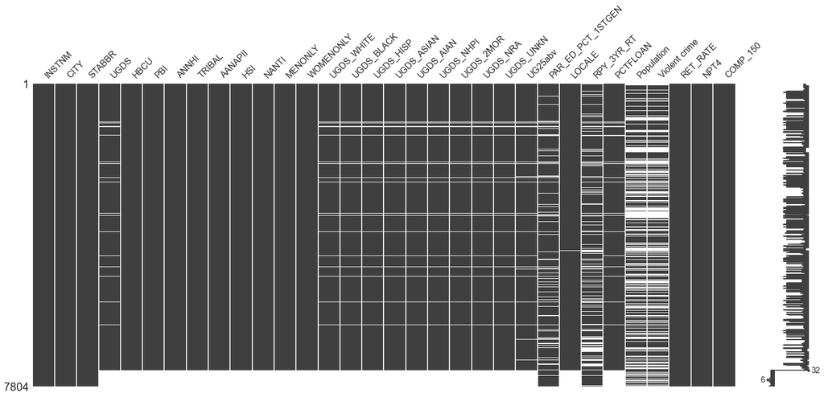

```python
# Check the density of null values

## The 'PAR_ED_PCT_1STGEN' have missing values in the form of 'PrivacySuppressed': we will change those to null values
df = df.replace('PrivacySuppressed', np.nan)

import missingno
missingno.matrix(df)
```

The 'Population' and 'Violent crime' columns (which were both imported from the crime dataset) have a relatively high density of null values. To check whether the crime data is relevant, we will create two separate dataframes; one containing the crime data, and the other without.

```
(5487, 30)
```

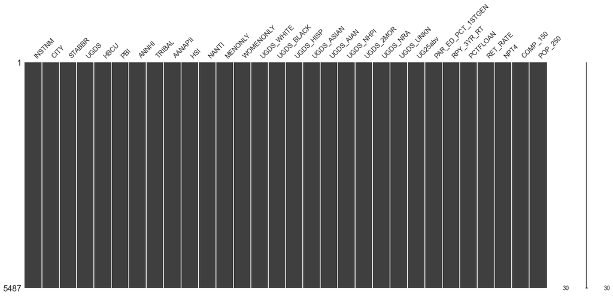

```python
# Create dataframe without 'Population' and 'Violent crime'

df_nocrime = df.drop(['Population', 'Violent crime'], axis = 1)

## compensate for the 'Population' column by turning the LOCALE into a categorical
df_nocrime['POP_250'] = (df_nocrime['LOCALE'] == 11) | (df_nocrime['LOCALE'] == 21)
df_nocrime['POP_250'] = df_nocrime['POP_250'].astype(int)
df_nocrime = df_nocrime.drop(['LOCALE'], axis = 1)

## Drop rows with null values
df_nocrime = df_nocrime.dropna()
missingno.matrix(df_nocrime)
print(df_nocrime.shape)
```

```
(3580, 31)
```

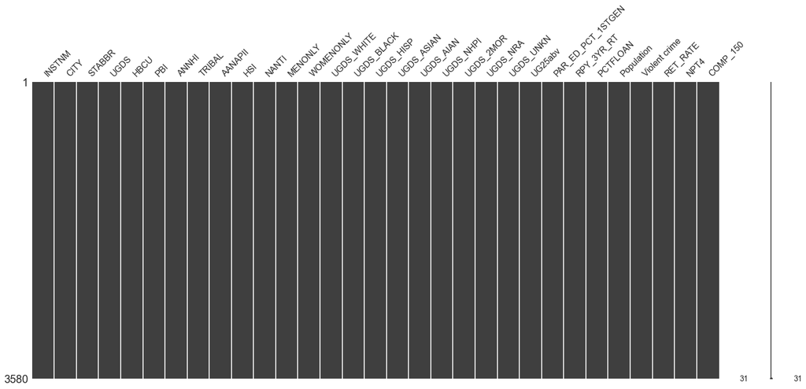

```python
# Create dataframe with 'Population' and 'Violent Crime' columns
df_crime = df.drop('LOCALE', axis = 1)
df_crime = df_crime.dropna()
missingno.matrix(df_crime)
print(df_crime.shape)
```

### Create a KMeans Function

Create a function that, using the kmeans model, -divides a given dataset into clusters  
-calculates the sillhouete score  
-visualizes the sillhouete score

```python
# Create function to create a clustered scatter plot and a visualization of the sillhouete score
# Inputs: data, number of clusters, the set of eigenvalues to plot by

def cluster_analysis (data, c_num, dim_1, dim_2, sil_score = True):
    kmeans_model = KMeans(n_clusters = c_num)
    kmeans_model.fit(data)
    data_kmeans = kmeans_model.predict(data)
    plt.scatter(data[:, dim_1],
                data[:, dim_2],
                c = data_kmeans,
                cmap = 'viridis')
    plt.show()

    if sil_score:
        visualizer = SilhouetteVisualizer(kmeans_model, colors = 'viridis')
        visualizer.fit(data)
        visualizer.show()
        silhouetteScore = silhouette_score(data, data_kmeans, metric = 'euclidean')
        print(f'Silhouette Score: {silhouetteScore}')
```

### Clustering the df_nocrime data

```python
# Create a 'df_nocrime' PCA model
df_nocrime_num = df_nocrime.drop(['INSTNM', 'CITY', 'STABBR'], axis = 1)
std_df_nocrime_num = preprocessing.scale(df_nocrime_num) # Standardize data before analysis
pca_nocrime = PCA(n_components = 27)
pca_nocrime.fit(std_df_nocrime_num)

print(f"The principal components are: \n{pca_nocrime.components_}")
print(f"The explained variances are: \n{pca_nocrime.explained_variance_}")
```

```
The principal components are:
[[ 1.72715418e-01 -7.33600486e-02 -3.15493582e-02  2.17922358e-02
  -7.03832986e-04  3.35484416e-02  8.43542061e-03  8.95198162e-03
   2.55950589e-02  5.44093652e-02  3.02998481e-01 -3.16749644e-01
  -1.10997977e-01  1.28048399e-01 -1.12114949e-02 -4.52874174e-03
   8.65214358e-02  2.68870342e-01 -7.57488931e-02 -3.93328926e-01
  -4.01535642e-01  4.42017021e-01 -1.48374470e-01  2.61085244e-01
   5.51293901e-02  1.66612064e-01 -1.40039596e-01]
 [ 3.04104804e-01 -8.39353097e-02  3.73697501e-02  1.52237966e-01
   2.94721351e-02  1.85762675e-01  3.28046132e-01  5.05566930e-02
  -3.76784278e-02 -4.54684233e-02 -2.73399502e-01 -1.29606379e-01
   3.73373194e-01  3.60141873e-01  5.74434373e-02  2.17094678e-01
   1.52662949e-01  8.65664763e-02 -4.10788208e-02  1.07335968e-02
   1.32153944e-01 -2.60881539e-02 -4.02219264e-01 -1.23272596e-02
  -2.59396488e-01 -1.55689205e-01  1.07602423e-01]
 [ 7.14093910e-02 -9.08063524e-02  2.36736195e-02 -7.24977498e-02
   1.28089407e-01 -7.52803697e-02  6.50157288e-02  1.35165351e-01
  -2.93117612e-02 -9.72192993e-02  3.60473716e-01 -1.56824957e-01
  -1.22574000e-01 -2.75091133e-01  2.20170312e-01 -1.72496680e-01
  -1.60529931e-01 -1.87056680e-01 -1.49511576e-01  3.66324277e-02
   1.06719656e-01 -3.05057881e-02 -2.59793277e-01 -1.61544593e-01
  -4.44355349e-01 -2.75125163e-01 -3.72802816e-01]
 [-1.47193828e-01 -1.86464780e-01 -6.50572321e-02  3.13873073e-01
   2.81787121e-01  1.09967042e-01 -2.24162116e-01  2.05903505e-01
  -3.07707688e-02 -1.37809547e-02  9.74420742e-02 -1.52358292e-01
  -2.41897185e-01  1.28159449e-01  3.91138948e-01  2.99631802e-01
   3.94947116e-01 -4.43777162e-02  1.90126135e-01  1.49682391e-01
  -3.87953601e-02  1.74631450e-02  1.36914274e-01 -1.98304578e-01
   1.22231210e-01 -1.16735489e-01  1.29786828e-02]
 [ 2.29090346e-01  5.02248441e-01  1.71950049e-01  1.10959030e-01
  -3.05325901e-02  1.08458831e-01 -5.03418962e-02  8.97670463e-03
   7.86731369e-02  5.28742359e-02 -1.12003027e-01  3.97679844e-01
  -3.71447070e-01  6.00362766e-02 -6.14004181e-02  9.89404252e-03
   8.73184060e-02  2.05280636e-01  5.43014780e-02 -1.20384669e-01
  -2.21082492e-01  4.08495753e-03 -3.90828268e-02 -1.82673898e-01
  -1.11013275e-01 -3.70452227e-01 -1.11331675e-01]
 [-9.73719145e-03  2.28034779e-01  1.13360731e-02 -1.64636033e-01
   4.85228290e-01 -1.13895763e-01  1.17646275e-01  3.09480653e-01
   6.14064627e-02  6.99713267e-02 -2.38757962e-01  1.35845174e-01
   1.64348350e-01 -7.78829093e-02  5.29651972e-01 -1.79084239e-01
```

[output cut: 143 more lines]

```
 [ 5.31480226e-07  3.68562180e-06 -6.86221101e-07  1.88624410e-06
   5.09615533e-06  2.43405280e-06 -2.34703697e-07 -1.45967717e-06
  -1.66385125e-06  2.98710843e-06  6.39460894e-01  5.18788472e-01
   4.69427271e-01  1.30868921e-01  7.11906980e-02  4.15529768e-02
   6.93170465e-02  7.63225368e-02  2.58910990e-01  6.41679822e-07
   1.49650866e-06 -2.75456177e-06  1.24387993e-06  2.29380630e-06
   7.43794153e-07  8.51657110e-07  4.55432877e-08]]
The explained variances are:
[3.62240426e+00 2.18786222e+00 2.00690751e+00 1.62784717e+00
 1.51424406e+00 1.47840440e+00 1.27015740e+00 1.05131372e+00
 1.01008083e+00 9.97902100e-01 9.78837093e-01 9.75114547e-01
 9.15172105e-01 8.45040044e-01 8.26121828e-01 7.60616370e-01
 6.87606779e-01 6.77307418e-01 6.23235823e-01 5.67982309e-01
 4.84381528e-01 4.72982120e-01 4.50221666e-01 4.23445071e-01
 3.41268322e-01 2.08464893e-01 3.73236152e-08]
```

We find that the first three eigenvectors have relativelly high explained variance values (>2).  
Variables that highly effect each eigenvector (variables which absolute eigenvalues are more than 0.3):

first eigenvector: percentage of white students, percentage of black students, ratio of studetns aged 25-64, ratio of self-reported first generation students, ratio of third year graduates who have started paying back their student loans  
second eigenvector: number of students, hispanic serving institutions, ratio of hispanic students, ratio of Asian students, percentage of students who received federal loans  
third eigenvector: percentage of white students, net price, population of city school is located in

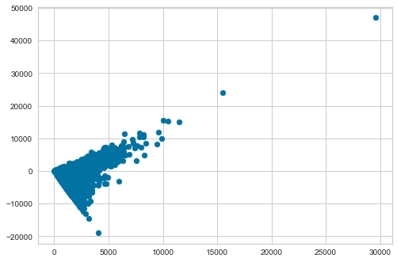

```python
# Explain the df_nocrime by the found eigenvectors
trans_nocrime = pca_nocrime.transform(df_nocrime_num)
plt.scatter(trans_nocrime[:, 0], trans_nocrime[:, 1])
```

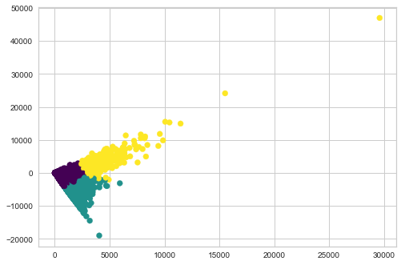

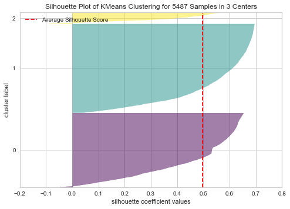

```
Silhouette Score: 0.4974454042595151
```

```python
cluster_analysis(trans_nocrime, 3, 0, 1)
```

Trying for other number of clusters (2 to 6), we find that the sillhouete score is highest when n_clusters = 3.

### Clustering the df_crime data

```python
# Create a 'df_crime' PCA model
df_crime_num = df_crime.drop(['INSTNM', 'CITY', 'STABBR'], axis = 1)
std_df_crime_num = preprocessing.scale(df_crime_num) # Standardize data before analysis
pca_crime = PCA(n_components = 28)
pca_crime.fit(std_df_crime_num)

print(f"The principal components are: \n{pca_crime.components_}")
print(f"The explained variances are: \n{pca_crime.explained_variance_}")
```

```
The principal components are:
[[ 1.76183565e-01 -7.95468561e-02 -3.52252074e-02  2.49079322e-02
   6.42518929e-03  3.56342103e-02  1.35069510e-02  1.57695359e-02
   2.27512831e-02  3.07737676e-02  3.10409338e-01 -3.22049594e-01
  -1.34453075e-01  1.24220139e-01 -2.55278334e-03 -1.48037618e-02
   1.15840877e-01  2.55750409e-01 -6.63803830e-02 -3.94008600e-01
  -4.09987466e-01  4.47224505e-01 -1.50804575e-01 -5.21966959e-02
  -6.93196337e-02  2.50875674e-01  3.42895809e-02  1.50988908e-01]
 [ 1.35525865e-01  8.55828301e-03  2.94623116e-02  3.35630172e-02
  -1.53826511e-02  8.63402923e-02  1.42942734e-01 -3.56817762e-02
  -3.92139431e-03  3.25377865e-02 -3.64569025e-01  4.54999842e-02
   2.75384375e-01  3.36048470e-01 -7.91211129e-02  1.10569462e-01
   8.13521260e-02  2.25816588e-01  4.63080849e-02 -3.93252470e-02
  -1.72372617e-02  4.46344223e-02 -9.23833129e-02  5.05587269e-01
   5.01379553e-01  8.20445229e-02  1.20511833e-01  8.05078850e-02]
 [ 3.14560833e-01 -1.02324859e-01  2.70669338e-02  5.20408972e-02
   2.54899674e-02  1.36546668e-01  3.21309591e-01  1.16186326e-01
  -2.44446390e-02 -7.37870891e-02 -1.14428296e-02 -1.78226677e-01
   2.01313126e-01  1.61879212e-01  1.24924100e-01  6.42720200e-02
   3.72514887e-02 -4.63311696e-02 -1.11005594e-01  4.82787691e-02
   2.04246330e-01 -4.54971670e-02 -4.73408485e-01 -1.28564041e-01
  -1.40385983e-01 -9.81788065e-02 -4.66952944e-01 -2.76928327e-01]
 [ 8.36554269e-02  7.62661250e-02  8.72237501e-02  6.95888804e-02
   6.23691777e-02 -2.93854095e-02 -1.06539422e-01  1.73878810e-01
  -9.99563014e-03  1.05208651e-02  1.31214649e-01  7.79161838e-02
  -4.41294581e-01 -2.62415208e-02  2.00196599e-01 -6.31790795e-02
   1.55614679e-01  1.12420433e-01  2.07754713e-01  8.50445299e-02
  -2.32656912e-01  7.32451475e-02  6.06899895e-03  2.33778236e-01
   2.37276658e-01 -4.07528575e-01 -8.91007054e-02 -4.83370854e-01]
 [-1.98414449e-01 -3.83947328e-01 -1.52817868e-01  2.00743043e-01
   4.81181246e-02 -1.27774244e-02 -9.94868143e-02  1.76279534e-01
  -7.87593079e-03 -4.16709452e-02 -2.58008802e-02 -3.48290651e-01
   9.74277795e-02  2.04398423e-01  2.67534588e-01  3.51239668e-01
   3.67588203e-01 -9.72337199e-02  2.50472835e-01  1.76046430e-01
   6.90969893e-02 -8.19049184e-03  1.43282952e-01 -6.21509730e-02
  -9.28083127e-02 -7.70114627e-02  2.27307395e-01  4.87582262e-02]
 [ 1.54186713e-01  4.20025619e-01  3.40502926e-02  1.95826343e-01
  -1.22384260e-02  1.93550487e-01 -1.58225277e-02 -1.23007239e-01
   6.45940690e-03  2.37808828e-02 -2.79107892e-01  2.81700032e-01
  -1.40862712e-01  2.79494763e-01 -1.62451530e-01  2.88482885e-01
```

[output cut: 150 more lines]

```
 [ 2.14997827e-06  7.14018821e-07 -2.58761831e-06  1.90473586e-07
   4.63046148e-06  2.78585666e-06  2.39855279e-07 -2.17127734e-09
  -4.13707393e-06  2.61768012e-06  6.43126445e-01  5.07266896e-01
   4.68151518e-01  1.41224860e-01  7.05282873e-02  4.47151397e-02
   6.66197859e-02  7.86549291e-02  2.68997937e-01  2.16681472e-06
   3.23739205e-06 -3.78483592e-07  2.63388558e-06  3.27968943e-06
  -1.53414807e-06  2.77235061e-06 -7.06313524e-07  3.60873386e-06]]
The explained variances are:
[3.49905832e+00 2.50612561e+00 2.06405059e+00 1.57466138e+00
 1.53242890e+00 1.38907625e+00 1.32361780e+00 1.13769500e+00
 1.02046270e+00 1.01000541e+00 1.00314831e+00 9.98666300e-01
 9.85167743e-01 9.46061089e-01 8.61435491e-01 8.11697071e-01
 7.69132573e-01 7.27686760e-01 6.49720270e-01 6.33441128e-01
 5.78633694e-01 4.75330672e-01 4.70069597e-01 4.44574300e-01
 3.59076290e-01 1.98862091e-01 3.79380458e-02 3.88738635e-08]
```

We find that the first three eigenvectors have relativelly high explained variance values (>2).  
Variables that highly effect each eigenvector (variables which absolute eigenvalues are more than 0.3):

first eigenvector: percentage of white students, percentage of black students, ratio of studetns aged 25-64, ratio of self-reported first generation students, ratio of third year graduates who have started paying back their student loans  
second eigenvector: percentage of white students, ratio of Asian students, population of city school is in, number of violent crimes school is in  
third eigenvector: school population, hispanic serving institutions, percentage of students who received federal loans, net price

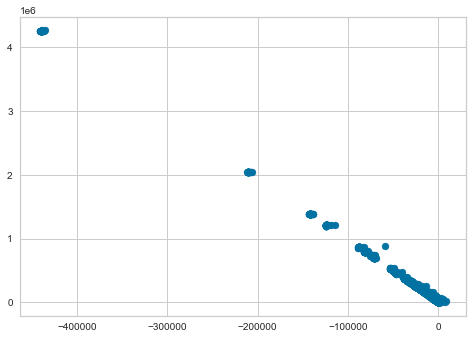

```python
# Explain the df_nocrime by the found eigenvectors
trans_crime = pca_crime.transform(df_crime_num)
plt.scatter(trans_crime[:, 0], trans_crime[:, 1])
```

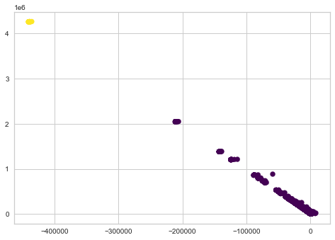

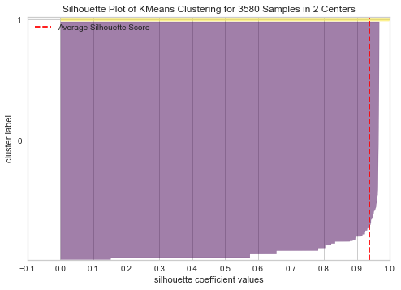

```
Silhouette Score: 0.937367230432614
```

```python
cluster_analysis(trans_crime, 2, 0, 1)
```

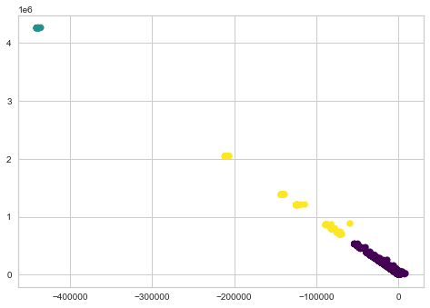

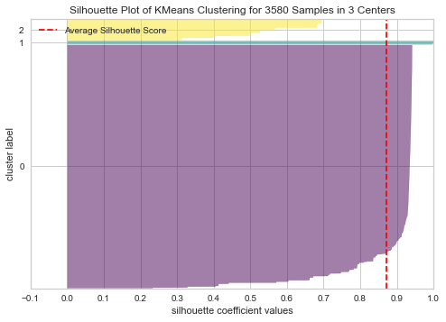

```
Silhouette Score: 0.8723859979174857
```

```python
cluster_analysis(trans_crime, 3, 0, 1)
```

Trying for other number of clusters, we find that n_cluster=2, 3 has relativelly high sillhouete values.

### Interpreting the Clusters

We will focus on the df_crime data, setting n_cluster = 3.  
Given that there are three eigenvectors with relativelly high variance contributions, we will plot three 2-D scatterplots, with each graph plotting the differenct convinations of the eigenvectors in question.

**Interpretations of each Eigenvector**  
By looking at the variables that influence each eigenvector, we can make meaning of what it means for a school to have a higher value for that vector. Eigenvector1:  
Higher proportion of white students, lower proportion of black students, students aged 25-64 and first-generation students. A higher proportion of third year graduates that started paying back their loans.  
Eigenvector2:  
Lower proportion of white students, higher proportion of Asian students. Higher population & violent crimes in city that school is located in.  
Eigenvector3:  
Bigger student population, more likely to be a hispanic serving school, a smaller ratio of students who received a federal loan, lower net price.

```
Eigenvectors 1 & 2
```

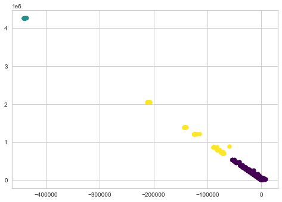

```
Eigenvectors 1 & 3
```

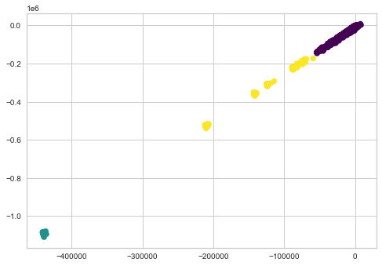

```
Eigenvectors 2 & 3
```

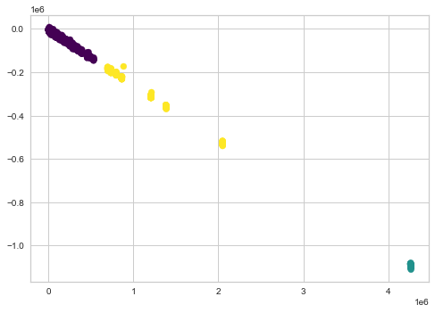

```python
print("Eigenvectors 1 & 2")
cluster_analysis(trans_crime, 3, 0, 1, sil_score = False)

print("Eigenvectors 1 & 3")
cluster_analysis(trans_crime, 3, 0, 2, sil_score = False)

print("Eigenvectors 2 & 3")
cluster_analysis(trans_crime, 3, 1, 2, sil_score = False)
```

Given the above graphs, we can make make certain generalizations about each cluster.

For example, we could argue that the purple cluster is likely to have the following traits:  
-Higher proportion of white students and a lower proportion of black students and Asian students  
-A lower proportion of students aged 25-64 and first-generation students  
-A higher proportion of third year graduates that started paying back their loans (potentially better employment)  
-Relativelly low population/violent crimes in the surrounding area  
-Bigger student body  
-A higher likely hood of being a hispanic serving school -Less students receiving a federal grant  
-Lower price

On the other hand, the blue cluster is likely to have opposite characteristics, while the yellow is more moderate.

The categories are reasonably consitent with one another; for example, simple math suggests that we can expect a relativelly lower proportion of black and Asian students if there is a higher proportion of white students. One may also argue that, given the current social structure in the US, schools with a higher proportion of white students are more likely to have more students that are able to begin paying back their student loans after three years of graduation (the validity of this claim is not obvious).

### Results/Concluding Remarks

The following variables had a eigenvalues for the eigenvectors with high variance contributions:

1. ratio of white students
2. ratio of black students
3. ratio of Asian students
4. ratio of students from 25-64
5. whether or not the school is a hispanic serving school
6. ratio of self-reported first-generation students
7. ratio of students who received federal loans
8. ratio of third-year graduates who started paying back their student loans
9. population of city that school is located in
10. Number of violent crimes in city that school is located in (only in the df_crime data)

Overall, variables 1-5 can be categorized as *demographical diversity*, variables 6-7 as *socio-economical diversity*, 8 as *post-graduation employment/stability*, 9 as *urban/transit*, and 10 as *safety*.  
It can be said that these categories reasonably cover the topics relevant to the issues that we wish to solve, such as school quality, safety, transit, and employment.